# THE WORLD ENERGY DATA ANALYSIS

## Presented to ...

### By: Hamidreza Rahbar

## Table of Contents:

1. Types of Energy
2. Getting Jupyter Ready
3. Reading and Understanding the data
4. Assumptions
5. Objectives
6. Data Cleaning and Manipulation
7. Data Modeling and Analysis
8. World Energy Overview

## 1. Types of Energy:

Energy generation and consumption can be categorized as follows:

- Fossil Energy: Coal, Oil, Gas, and Low-Carbon Fuels
- Nuclear Energy
- Renewable Energy: Hydro, Wind, Solar, Biofuel, and other Renewable Sources

## 2. Getting Jupyter Ready:

### 2.1 Import Python Libraries:

```python
# data manipulation
import pandas as pd
import numpy as np
from sklearn import datasets

# data viz
import matplotlib.pyplot as plt
from matplotlib import rcParams
import seaborn as sns
import geopandas
import folium
import ipywidgets as widgets
from ipywidgets import interact, interact_manual
```

### 2.2 Adjust Views:

```python
# apply some cool styling
plt.style.use("ggplot")
rcParams['figure.figsize'] = (12, 6)

pd.set_option('display.max_rows', 500)
pd.set_option('display.max_columns', 500)
pd.set_option('display.width', 1000)
pd.set_option('display.expand_frame_repr', False)
```

## 3. Reading and Understanding the Data:

### 3.1 Importing Data:

```python
#Importing Data
df_WE_all = pd.read_csv('owid-energy-data.csv')
```

### 3.2 Inspect DataFrame:

```python
# Database dimension
print("Database dimension - df_WE_all:",df_WE_all.shape)

#Database size
print("Database size      - df_WE_all:",df_WE_all.size)
```

```
Database dimension - df_WE_all: (21861, 129)
Database size      - df_WE_all: 2820069
```

```python
# Database column types
#df_WE_all.info(verbose=True, show_counts = True)
```

### 3.3 Understanding Data:

```python
# Reviewing some of the data
df_WE_all.head()
```

|  | country | year | iso_code | population | gdp | biofuel_cons_change_pct | biofuel_cons_change_twh | biofuel_cons_per_capita | biofuel_consumption | biofuel_elec_per_capita | biofuel_electricity | biofuel_share_elec | biofuel_share_energy | carbon_intensity_elec | coal_cons_change_pct | coal_cons_change_twh | coal_cons_per_capita | coal_consumption | coal_elec_per_capita | coal_electricity | coal_prod_change_pct | coal_prod_change_twh | coal_prod_per_capita | coal_production | coal_share_elec | coal_share_energy | electricity_demand | electricity_generation | electricity_share_energy | … |
| --- | --- | --- | --- | --- | --- | --- | --- | --- | --- | --- | --- | --- | --- | --- | --- | --- | --- | --- | --- | --- | --- | --- | --- | --- | --- | --- | --- | --- | --- | --- |
| 0 | Afghanistan | 1900 | AFG | 4832414.0 | NaN | NaN | NaN | NaN | NaN | NaN | NaN | NaN | NaN | NaN | NaN | NaN | NaN | NaN | NaN | NaN | NaN | NaN | 0.0 | 0.0 | NaN | NaN | NaN | NaN | NaN | … |
| 1 | Afghanistan | 1901 | AFG | 4879685.0 | NaN | NaN | NaN | NaN | NaN | NaN | NaN | NaN | NaN | NaN | NaN | NaN | NaN | NaN | NaN | NaN | NaN | 0.0 | 0.0 | 0.0 | NaN | NaN | NaN | NaN | NaN | … |
| 2 | Afghanistan | 1902 | AFG | 4935122.0 | NaN | NaN | NaN | NaN | NaN | NaN | NaN | NaN | NaN | NaN | NaN | NaN | NaN | NaN | NaN | NaN | NaN | 0.0 | 0.0 | 0.0 | NaN | NaN | NaN | NaN | NaN | … |
| 3 | Afghanistan | 1903 | AFG | 4998861.0 | NaN | NaN | NaN | NaN | NaN | NaN | NaN | NaN | NaN | NaN | NaN | NaN | NaN | NaN | NaN | NaN | NaN | 0.0 | 0.0 | 0.0 | NaN | NaN | NaN | NaN | NaN | … |
| 4 | Afghanistan | 1904 | AFG | 5063419.0 | NaN | NaN | NaN | NaN | NaN | NaN | NaN | NaN | NaN | NaN | NaN | NaN | NaN | NaN | NaN | NaN | NaN | 0.0 | 0.0 | 0.0 | NaN | NaN | NaN | NaN | NaN | … |

```python
# Reviewing some of the data
df_WE_all.tail()
```

|  | country | year | iso_code | population | gdp | biofuel_cons_change_pct | biofuel_cons_change_twh | biofuel_cons_per_capita | biofuel_consumption | biofuel_elec_per_capita | biofuel_electricity | biofuel_share_elec | biofuel_share_energy | carbon_intensity_elec | coal_cons_change_pct | coal_cons_change_twh | coal_cons_per_capita | coal_consumption | coal_elec_per_capita | coal_electricity | coal_prod_change_pct | coal_prod_change_twh | coal_prod_per_capita | coal_production | coal_share_elec | coal_share_energy | electricity_demand | electricity_generation | electricity_share_energy | … |
| --- | --- | --- | --- | --- | --- | --- | --- | --- | --- | --- | --- | --- | --- | --- | --- | --- | --- | --- | --- | --- | --- | --- | --- | --- | --- | --- | --- | --- | --- | --- |
| 21856 | Zimbabwe | 2017 | ZWE | 14751101.0 | 2.194784e+10 | NaN | NaN | NaN | NaN | 21.693 | 0.32 | 4.354 | NaN | 363.265 | NaN | NaN | NaN | NaN | 204.730 | 3.02 | 8.375 | 1.697 | 1488.509 | 21.957 | 41.088 | NaN | 9.57 | 7.35 | NaN | … |
| 21857 | Zimbabwe | 2018 | ZWE | 15052191.0 | 2.271535e+10 | NaN | NaN | NaN | NaN | 25.910 | 0.39 | 4.244 | NaN | 355.822 | NaN | NaN | NaN | NaN | 245.147 | 3.69 | 14.336 | 3.148 | 1667.861 | 25.105 | 40.152 | NaN | 10.21 | 9.19 | NaN | … |
| 21858 | Zimbabwe | 2019 | ZWE | 15354606.0 | NaN | NaN | NaN | NaN | NaN | 24.748 | 0.38 | 4.612 | NaN | 387.136 | NaN | NaN | NaN | NaN | 235.760 | 3.62 | -21.529 | -5.405 | 1283.004 | 19.700 | 43.932 | NaN | 9.35 | 8.24 | NaN | … |
| 21859 | Zimbabwe | 2020 | ZWE | 15669663.0 | NaN | NaN | NaN | NaN | NaN | 22.336 | 0.35 | 4.605 | NaN | 389.474 | NaN | NaN | NaN | NaN | 215.065 | 3.37 | 3.004 | 0.592 | 1294.978 | 20.292 | 44.342 | NaN | 9.58 | 7.60 | NaN | … |
| 21860 | Zimbabwe | 2021 | ZWE | 15993525.0 | NaN | NaN | NaN | NaN | NaN | 23.760 | 0.38 | 4.726 | NaN | 393.035 | NaN | NaN | NaN | NaN | 223.841 | 3.58 | 19.708 | 3.999 | 1518.799 | 24.291 | 44.527 | NaN | 9.79 | 8.04 | NaN | … |

```python
# Understanding the country column data
#pd.DataFrame(df_WE_all.country.unique()).reset_index()
```

### 3.4 Granularity of the data and data broad category:

#### Understanding the Similar Columns Data:

[figure not shown]

#### Granularity of the data:

The grain of the data in the "World Energy" is at the country level. Each record in the dataset represents a single country or region, and the information available in the data fields is related to that country or region. The data fields in the dataset provide information about the differetn type of energy consumption on annual basis. The data is organized and sorted by the name of eachcountry and region, which further reinforces that the grain of the data is at the country level.

**Insight:**  
- The dataset consists of 21861 energy related data for 305 countries and regions from 1900 to 2021 in 129 fields.  
- Column's type are object, int64, and float64 and it seems each field's type conform with its content, so there is no need for correction.  
- However, there are some data that pertains to the continents. Additionally, some other data refers to names of regions or part of some continents that only the creator of the dataset can interpret. As a result, not all the data can be utilized and the data requires cleaning

## 4. Assumptions:

- The G7 countries considered for analysis in this report, including: United States, Canada, United Kingdom, France, Germany, Italy, and Japan.
- The period of 31 years, from 1990 to 2021, also consider for the analysis.
- Here is the link to the dataset source: [Click Here](https://github.com/owid/energy-data)

## 5. Objectives:

The objective of this analysis is to answer the following questions:

1. Which country consumes the most energy in the world?
2. What is the energy consumption per capita or per GDP for each country?
3. What is the percentage of energy consumption that is electricity?
4. How does the consumption of primary energy sources (fossil, nuclear, renewable) compare?
5. Which source of energy has grown the most over the last 30 years?
6. Energy production patterns in different countries, including the source of energy production, such as coal, gas, oil, or biofuels.
7. Energy consumption patterns in different countries, including per capita energy consumption, the share of energy consumption from different sources, and the change in energy consumption over time.
8. Energy production and consumption trends in different countries, including the annual change in energy production or consumption and the share of energy production or consumption in different energy sources.
9. The relationship between energy production, consumption, and economic indicators, such as GDP, population, and energy consumption per GDP.
10. The environmental impact of energy production and consumption, including greenhouse gas emissions and carbon intensity of electricity production.

## 6. Data Cleaning and Manipulation

```python
# Creating new DataFrame for the assumed data G7 Countries
G7_Countries = ['United States', 'Canada',  'United Kingdom', 'France',  'Germany', 'Italy',    'Japan']
G7_Color     = ['#002868',       '#FF0000', '#C8102E',        '#0055A4', '#FFCE00',  '#009246', '#be0029']
#G7_Color    = ['#BF0A30',       '#FFFFFF', '#012169',        '#EF4135', '#DD0000',  '#CE2B37', '#ffffff']
#e6ffe6
#ffe6e6

df_WE_G7 = df_WE_all[df_WE_all.country.isin(G7_Countries) & df_WE_all.year.between(1990, 2021)]

pd.DataFrame(df_WE_G7.country.unique()).reset_index()
```

|  | index | 0 |
| --- | --- | --- |
| 0 | 0 | Canada |
| 1 | 1 | France |
| 2 | 2 | Germany |
| 3 | 3 | Italy |
| 4 | 4 | Japan |
| 5 | 5 | United Kingdom |
| 6 | 6 | United States |

```python
# Changing the name of some columns in G7 dataframe
df_WE_G7 = df_WE_G7.rename(columns={
                   'gdp':                           'GDP',
                   'energy_per_capita':             'Energy_Consumption_PerCapita',
                   'energy_per_gdp':                'Energy_Consumption_PerGDP',
                   'net_elec_imports':              'Net_Electricity_Imports',
                   'net_elec_imports_share_demand': '%Electricity_Imports_As_Demand',
                   'electricity_demand':            'Electricity_Demand',
                   'electricity_generation':        'Electricity_Generation',
                   'electricity_share_energy':      '%Electricity_As_Energy',
                   'per_capita_electricity':        'Electricity_Comsumption_PerCapita',
                   'primary_energy_consumption':    'Total_Energy_Consumption',
                   'population':                    'Population'})
```

### 6.1 Correlations:

```python
# Checking is there any correlation among the general columns data:
corr_col = ['GDP', 'Population', 'Energy_Consumption_PerCapita', 'Energy_Consumption_PerGDP',
            'Net_Electricity_Imports', '%Electricity_Imports_As_Demand','Electricity_Demand',
            'Electricity_Generation', '%Electricity_As_Energy', 'Electricity_Comsumption_PerCapita',
             'Total_Energy_Consumption']

df_corr_matrix = df_WE_G7[corr_col].corr()

# Remoivng the upper part of the correlation matrix
df_corr_lower = df_corr_matrix.where(np.tril(np.ones(df_corr_matrix.shape),k=-1).astype(np.bool_))

# Removing non-correlated variables
df_corr_lower.mask((df_corr_lower.values < 0.5) & (df_corr_lower.values > -0.5), np.nan, inplace=True)

#df_corr_lower
```

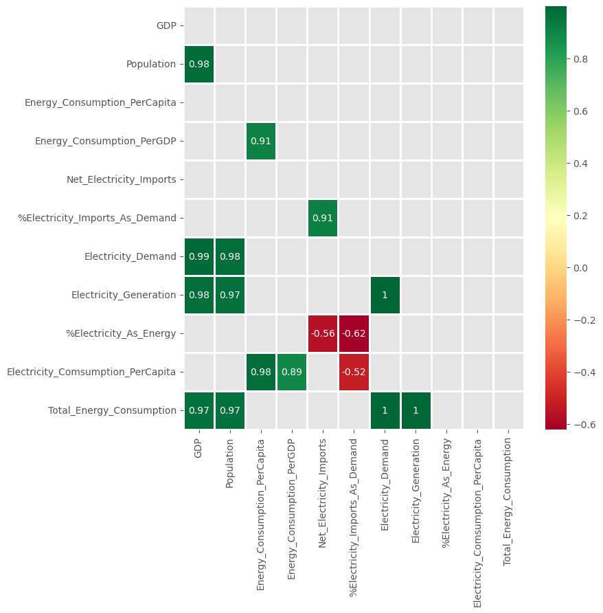

```python
# Visualizing the correlated variables in the G7 DataFrame

fig = plt.figure(figsize=(8,8))
ax = sns.heatmap(df_corr_lower,
            xticklabels=df_corr_lower.columns,
            yticklabels=df_corr_lower.columns,
            annot = True,
            cmap ="RdYlGn",
            linewidth=1)
```

```python
# Changing the name of some other columns in G7 dataframe
df_WE_G7 = df_WE_G7.rename(columns={
                    'fossil_elec_per_capita':       'Electricity_from_Fossil_PerCapita',
                    'fossil_energy_per_capita':     'Fossil_Consumption_PerCapita',
                    'fossil_share_elec':            '%Electricity_from_Fossil',
                    'fossil_share_energy':          '%Energy_from_Fossil',
                    'nuclear_elec_per_capita':      'Electricity_from_Nuclear_PerCapita',
                    'nuclear_energy_per_capita':    'Nuclear_Consumption_PerCapita',
                    'nuclear_share_elec':           '%Electricity_from_Nuclear',
                    'nuclear_share_energy':         '%Energy_from_Nuclear',
                    'renewables_elec_per_capita':   'Electricity_from_Renewables_PerCapita',
                    'renewables_energy_per_capita': 'Renewables_Consumption_PerCapita',
                    'renewables_share_elec':        '%Electricity_from_Renewables',
                    'renewables_share_energy':      '%Energy_from_Renewables'})
```

```python
# Checking is there any correlation among the general columns data:
corr_col = ['GDP', 'Population', 'Energy_Consumption_PerCapita', 'Energy_Consumption_PerGDP',
            'Net_Electricity_Imports', '%Electricity_Imports_As_Demand','Electricity_Demand',
            'Electricity_Generation', '%Electricity_As_Energy', 'Electricity_Comsumption_PerCapita',
            'Total_Energy_Consumption', 'Electricity_from_Fossil_PerCapita', 'Fossil_Consumption_PerCapita',
            '%Electricity_from_Fossil', '%Energy_from_Fossil', 'Electricity_from_Nuclear_PerCapita',
            'Nuclear_Consumption_PerCapita', '%Electricity_from_Nuclear', '%Energy_from_Nuclear',
            'Electricity_from_Renewables_PerCapita', 'Renewables_Consumption_PerCapita',
            '%Electricity_from_Renewables', '%Energy_from_Renewables']

df_corr_matrix = df_WE_G7[corr_col].corr()

# Remoivng the upper part of the correlation matrix
df_corr_lower = df_corr_matrix.where(np.tril(np.ones(df_corr_matrix.shape),k=-1).astype(np.bool_))

# Removing non-correlated variables
df_corr_lower.mask((df_corr_lower.values < 0.5) & (df_corr_lower.values > -0.5), np.nan, inplace=True)

#df_corr_lower
```

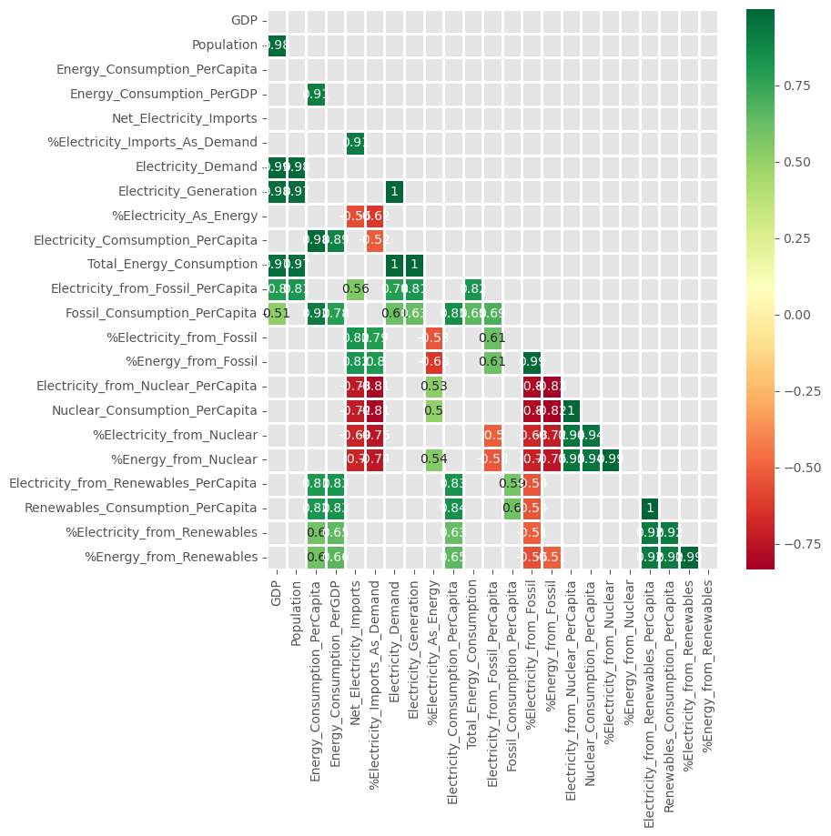

```python
# Visualizing the correlated variables in the G7 DataFrame

fig = plt.figure(figsize=(8,8))
ax = sns.heatmap(df_corr_lower,
            xticklabels=df_corr_lower.columns,
            yticklabels=df_corr_lower.columns,
            annot = True,
            cmap ="RdYlGn",
            linewidth=1)
```

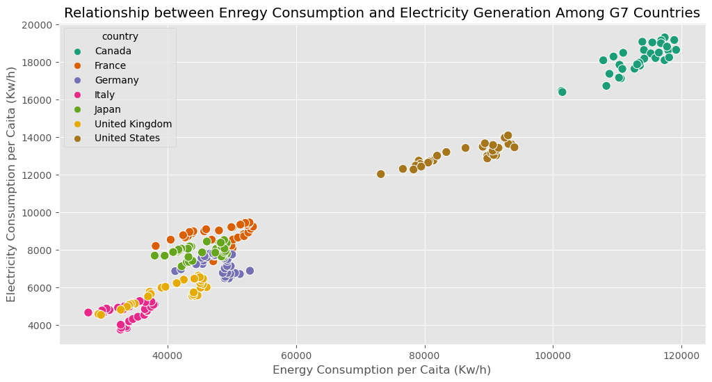

```python
sns.scatterplot(x="Energy_Consumption_PerCapita", y="Electricity_Comsumption_PerCapita", hue="country", data=df_WE_G7, palette="Dark2", s=80)
plt.title("Relationship between Enregy Consumption and Electricity Generation Among G7 Countries")
plt.xlabel("Energy Consumption per Caita (Kw/h)")
plt.ylabel("Electricity Consumption per Caita (Kw/h)")
plt.show()
```

## 7. Data Modeling and Analysis

### 7.1 Energy and Electricity Comsumption:

[output not shown]

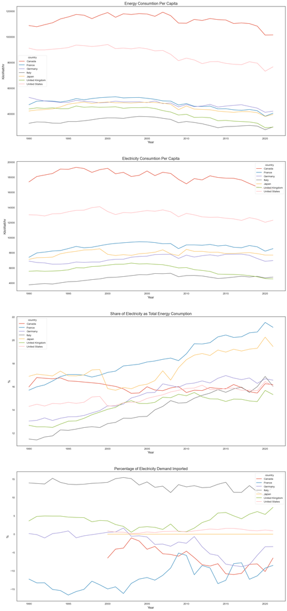

```python
# Set the style
sns.set_style("white")

fig, axes = plt.subplots(4, 1, figsize=(18, 40))

sns.lineplot(ax=axes[0], data=df_WE_G7, x='year', y='Energy_Consumption_PerCapita', hue = 'country')
axes[0].set(xlabel ="Year", ylabel = "KiloWatt/hr", title ='Energy Consumtion Per Capita')

sns.lineplot(ax=axes[1], data=df_WE_G7, x='year', y='Electricity_Comsumption_PerCapita', hue = 'country')
axes[1].set(xlabel ="Year", ylabel = "KiloWatt/hr", title ='Electricity Consumtion Per Capita')

sns.lineplot(ax=axes[2], data=df_WE_G7, x='year', y='%Electricity_As_Energy', hue = 'country')
axes[2].set(xlabel ="Year", ylabel = "%", title ='Share of Electricity as Total Energy Conumption')

sns.lineplot(ax=axes[3], data=df_WE_G7, x='year', y='%Electricity_Imports_As_Demand', hue = 'country')
axes[3].set(xlabel ="Year", ylabel = "%", title ='Percentage of Electricity Demand Imported')
```

**Insights:**  
1. Canada has a high energy and electricity consumption per capita compared to other G7 countries.  
2. Electricity is widely considered to be a clean energy source due to its low emissions and pollution levels. As the world shifts towards more sustainable energy solutions, the use of electricity has become increasingly popular. In particular, among the G7 countries, the share of electricity in their total energy consumption has been on the rise, especially in France and Japan. These countries have made significant investments in renewable energy sources such as wind, solar, and hydro power, which has helped increase the share of electricity in their energy mix. This trend towards cleaner energy sources is expected to continue as countries work towards reducing their carbon footprint and meeting international climate goals.  
3. Italy is among the largest importers of electricity among the G7 countries, relying heavily on foreign sources to meet its energy needs. On the other hand, France, Canada, and Germany are significant exporters of electricity, with France ranking as the top exporter among the G7 countries. These countries have established themselves as major players in the global energy market, leveraging their abundant natural resources, and modern energy infrastructure. However, Japan stands out as a unique case among the G7 countries, with no imports or exports of electricity. This is due to the country's focus on energy self-sufficiency, which is achieved through a combination of energy efficiency measures and investments in its own energy infrastructure, including nuclear power and renewable energy sources. These diverse energy dynamics among the G7 countries highlight the importance of energy trade and cooperation in the global energy market.

### 7.2 Annual Changes in Energy consumption:

```python
# Changing the name of some other columns in G7 dataframe
df_WE_G7 = df_WE_G7.rename(columns={
                    'energy_cons_change_twh':     'Annual_Change_in_Energy_Consumption',
                    'fossil_cons_change_twh':     'Annual_Change_in_Fossil_Energy_Consumption',
                    'nuclear_cons_change_twh':    'Annual_Change_in_Nuclear_Energy_Consumption',
                    'renewables_cons_change_twh': 'Annual_Change_in_Renewable_Energy_Consumption'})
```

```
[Text(0.5, 1.0, 'Annual Change'), Text(0.5, 0, 'Year')]
```

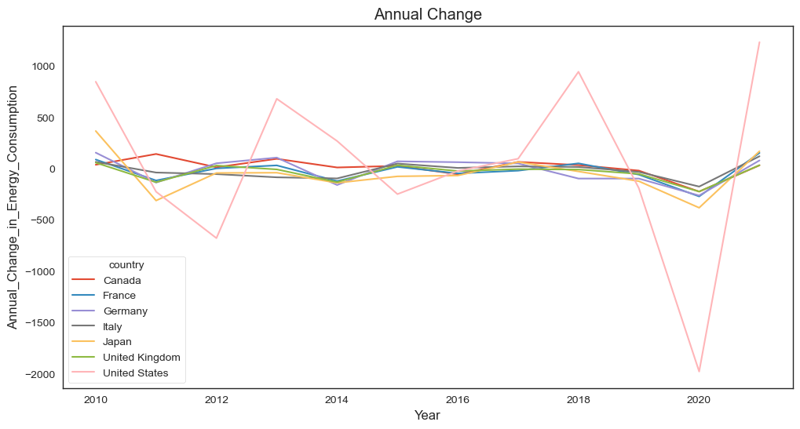

```python
# The original plot was interactive, but I modified it to be non-interactive for conversion to an HTML file.
# To make the plot interactive again, uncomment the code inside the f function and adjust its indentation.

energyType = ['Annual_Change_in_Energy_Consumption', 'Annual_Change_in_Fossil_Energy_Consumption', 'Annual_Change_in_Nuclear_Energy_Consumption', 'Annual_Change_in_Renewable_Energy_Consumption']
EnergyType = 'Annual_Change_in_Energy_Consumption'

#@interact(EnergyType = energyType)

#def f(EnergyType):
df2 = df_WE_G7[df_WE_G7.year >= 2010]
sns.lineplot(x="year", y=EnergyType, data=df2, hue='country').set(title = "Annual Change", xlabel='Year')
#    return
```

### 7.3 Outliers analysis:

```
[Text(0.5, 1.0, 'Annual Change'), Text(0.5, 0, 'Year')]
```

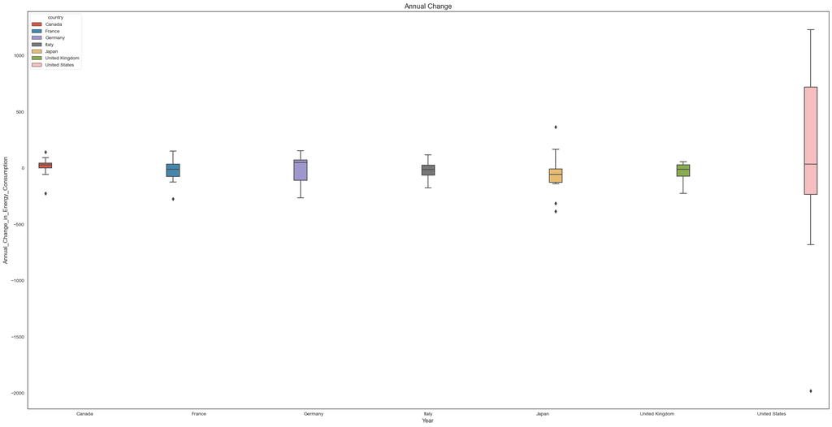

```python
# The original plot was interactive, but I modified it to be non-interactive for conversion to an HTML file.
# To make the plot interactive again, uncomment the code inside the f function and adjust its indentation.

plt.figure(figsize = (30, 15))

#@interact(EnergyType = energyType)

#def f(EnergyType):
df2 = df_WE_G7[df_WE_G7.year >= 2010]
sns.boxplot(data=df2, x = 'country', y = EnergyType, hue = "country", showfliers=True).set(title = "Annual Change", xlabel='Year')
#    return
```

```python
df_sort = df_WE_G7[df_WE_G7['country'] == 'United States'].reindex(df_WE_G7['Annual_Change_in_Energy_Consumption'].abs().sort_values(ascending=False).index).reset_index()
df_sort = df_sort[df_sort['year'].notnull()].head(5)
df_sort[['country', 'year', 'Annual_Change_in_Energy_Consumption']].sort_values('year')
```

|  | country | year | Annual_Change_in_Energy_Consumption |
| --- | --- | --- | --- |
| 1 | United States | 2009.0 | -1299.984 |
| 4 | United States | 2010.0 | 846.334 |
| 3 | United States | 2018.0 | 943.441 |
| 0 | United States | 2020.0 | -1978.438 |
| 2 | United States | 2021.0 | 1232.238 |

```python
df_sort = df_WE_G7[df_WE_G7['country'] == 'United States'].reindex(df_WE_G7['Annual_Change_in_Fossil_Energy_Consumption'].abs().sort_values(ascending=False).index).reset_index()
df_sort = df_sort[df_sort['year'].notnull()].head(5)
df_sort[['country', 'year', 'Annual_Change_in_Fossil_Energy_Consumption']].sort_values('year')
```

|  | country | year | Annual_Change_in_Fossil_Energy_Consumption |
| --- | --- | --- | --- |
| 4 | United States | 2008.0 | -781.326 |
| 1 | United States | 2009.0 | -1399.760 |
| 3 | United States | 2018.0 | 896.049 |
| 0 | United States | 2020.0 | -2033.705 |
| 2 | United States | 2021.0 | 1109.158 |

```python
df_sort = df_WE_G7[df_WE_G7['country'] == 'Japan'].reindex(df_WE_G7['Annual_Change_in_Nuclear_Energy_Consumption'].abs().sort_values(ascending=False).index).reset_index()
df_sort = df_sort[df_sort['year'].notnull()].head(5)
df_sort[['country', 'year', 'Annual_Change_in_Nuclear_Energy_Consumption']].sort_values('year')
```

|  | country | year | Annual_Change_in_Nuclear_Energy_Consumption |
| --- | --- | --- | --- |
| 14 | Japan | 1993.0 | 87.012 |
| 2 | Japan | 2003.0 | -239.913 |
| 4 | Japan | 2004.0 | 150.188 |
| 1 | Japan | 2011.0 | -347.368 |
| 0 | Japan | 2012.0 | -383.962 |

```python
df_sort = df_WE_G7[df_WE_G7['country'] == 'Germany'].reindex(df_WE_G7['Annual_Change_in_Renewable_Energy_Consumption'].abs().sort_values(ascending=False).index).reset_index()
df_sort = df_sort[df_sort['year'].notnull()].head(5)
df_sort[['country', 'year', 'Annual_Change_in_Renewable_Energy_Consumption']].sort_values('year')
```

|  | country | year | Annual_Change_in_Renewable_Energy_Consumption |
| --- | --- | --- | --- |
| 35 | Germany | 2007.0 | 53.185 |
| 34 | Germany | 2011.0 | 53.837 |
| 31 | Germany | 2012.0 | 55.560 |
| 23 | Germany | 2015.0 | 67.710 |
| 22 | Germany | 2017.0 | 69.096 |

```python
df_sort = df_WE_G7[df_WE_G7['country'] == 'United Kingdom'].reindex(df_WE_G7['Annual_Change_in_Renewable_Energy_Consumption'].abs().sort_values(ascending=False).index).reset_index()
df_sort = df_sort[df_sort['year'].notnull()].head(5)
df_sort[['country', 'year', 'Annual_Change_in_Renewable_Energy_Consumption']].sort_values('year')
```

|  | country | year | Annual_Change_in_Renewable_Energy_Consumption |
| --- | --- | --- | --- |
| 66 | United Kingdom | 2013.0 | 35.228 |
| 39 | United Kingdom | 2015.0 | 50.661 |
| 50 | United Kingdom | 2017.0 | 42.300 |
| 59 | United Kingdom | 2020.0 | 38.847 |
| 64 | United Kingdom | 2021.0 | -35.879 |

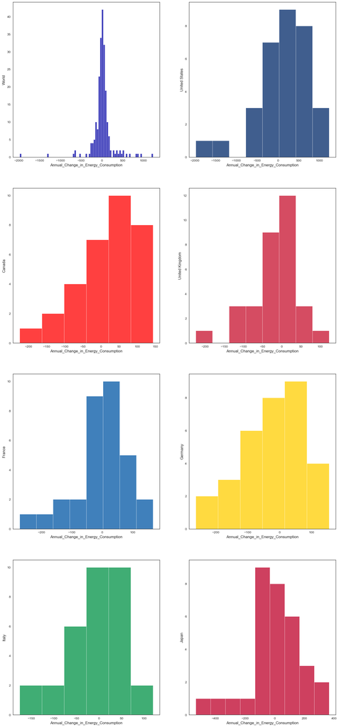

```python
# Making Histolpot for annual energy consumption

# Set the style
sns.set_style("white")

fig, axes = plt.subplots(4, 2, figsize=(18, 40))
i=0
j=0

sns.histplot(ax=axes[0, 0], data=df_WE_G7, x='Annual_Change_in_Energy_Consumption', color='#0000A5')
axes[0, 0].set(ylabel = 'World')

for C in G7_Countries:
    if j==1:
        j=0
        i+=1
    else:
        j+=1
    sns.histplot(ax=axes[i, j], data=df_WE_G7[df_WE_G7.country == C], x='Annual_Change_in_Energy_Consumption', color = G7_Color[G7_Countries.index(C)])
    axes[i, j].set(ylabel = C)
```

**Insights:**  
1. The energy consumption patterns in the United States have experienced annual fluctuations over the last 10 years. This is true for both fossil and renewable energy sources, with shifts in consumption levels reflecting changes in the economy, energy prices, and government policies. Over this time period, the United States has experienced periods of increased energy consumption, as well as periods of reduced consumption during economic downturns. These fluctuations highlight the complex interplay between energy demand and economic conditions, as well as the ongoing transition towards a more sustainable energy mix. Despite the fluctuations, renewable energy sources have gained a greater share of the energy mix over the last few decades, reflecting the country's growing commitment to reducing its carbon footprint and increasing its use of clean energy sources.  
2. The United States has experienced reductions in energy and electricity consumption in recent years, specifically in 2008, 2009, and 2020. The reductions in 2008 and 2009 were primarily driven by the global financial crisis and its impact on the economy, leading to a decrease in industrial activity and energy demand. In 2020, the reduction in energy consumption was largely due to the COVID-19 pandemic, which resulted in widespread lockdowns, reductions in travel and economic activity, and a decrease in energy demand. These reductions in energy consumption demonstrate the responsiveness of the energy system to changes in economic conditions and highlight the importance of energy efficiency measures in reducing overall energy demand. As the country looks to recover from the pandemic and address its long-term energy challenges, it will be important to consider both economic and environmental factors in shaping its energy policies and investments.  
3. The other G7 countries are making efforts to reduce their dependence on nuclear energy and increase investment in renewable energy sources. This shift towards a cleaner energy mix reflects a growing recognition of the environmental and health risks associated with nuclear power, as well as the increasing competitiveness of renewable energy technologies. In particular, Japan stands out as a leader in this transition, with a significant reduction in its use of nuclear energy between 2010 and 2011. This reduction was a direct response to the Fukushima disaster in 2011, which raised concerns about the safety of nuclear power in the country and led to a shift towards alternative energy sources. These efforts towards reducing the use of nuclear energy and increasing investment in renewable energy demonstrate the commitment of G7 countries to creating a more sustainable and secure energy future.  
4. Germany and the United Kingdom have both seen increases in the use of renewable energy in recent years. In Germany, the use of renewable energy sources grew rapidly between 2007 and 2017, reflecting the country's ambitious energy transition policies and its commitment to reducing its carbon footprint. This increase in renewable energy was driven by a combination of policy support, investments in renewable energy infrastructure, and advancements in renewable energy technologies. Similarly, the United Kingdom experienced a significant increase in the use of renewable energy between 2013 and 2020, reflecting the country's efforts to transition away from fossil fuels and towards a cleaner energy mix. This increase in renewable energy was driven by policy support, including government incentives and regulations, as well as the declining cost of renewable energy technologies. These trends demonstrate the progress that can be made in transitioning towards a more sustainable energy system and highlight the importance of continued investment and policy support in the renewable energy sector.

### 7.4 Energy consumption by sources:

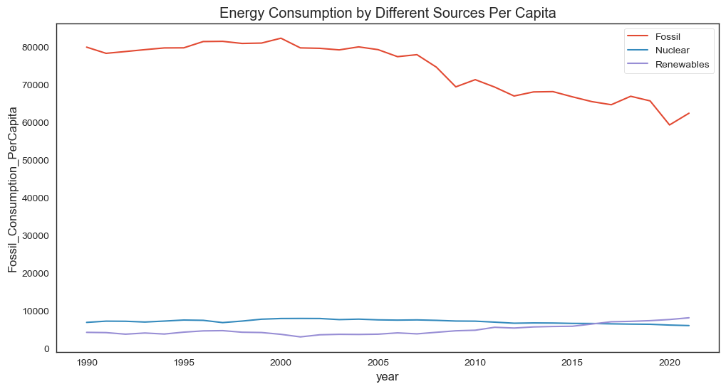

```python
# The original plot was interactive, but I modified it to be non-interactive for conversion to an HTML file.
# To make the plot interactive again, uncomment the code inside the f function and adjust its indentation.

Country = 'United States'

#@interact(Country = G7_Countries)

#def f(Country):
df2 = df_WE_G7[df_WE_G7['country'] == Country]
sns.lineplot(x="year", y="Fossil_Consumption_PerCapita", data=df2, label='Fossil').set(title = "Energy Consumption by Different Sources Per Capita")
sns.lineplot(x="year", y="Nuclear_Consumption_PerCapita", data=df2, label='Nuclear')
sns.lineplot(x="year", y="Renewables_Consumption_PerCapita", data=df2, label='Renewables')
#    return
```

### 7.5 Electricity consumption by sources:

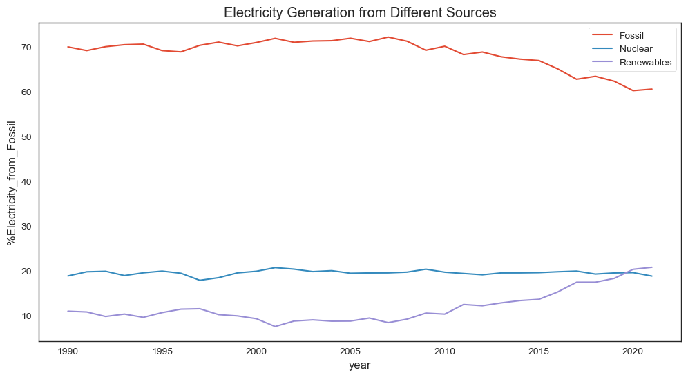

```python
# The original plot was interactive, but I modified it to be non-interactive for conversion to an HTML file.
# To make the plot interactive again, uncomment the code inside the f function and adjust its indentation.

#@interact(Country = G7_Countries)

#def f(Country):
df2 = df_WE_G7[df_WE_G7['country'] == Country]
sns.lineplot(x="year", y="%Electricity_from_Fossil", data=df2, label='Fossil').set(title = "Electricity Generation from Different Sources")
sns.lineplot(x="year", y="%Electricity_from_Nuclear", data=df2, label='Nuclear')
sns.lineplot(x="year", y="%Electricity_from_Renewables", data=df2, label='Renewables')
#    return
```

**Insights:**  
1. The energy mix for electricity production among the G7 countries varies greatly, with each country having its own unique approach to balancing its energy sources.  
2. The United States has long been reliant on fossil fuels for electricity production, but has started to invest in renewable energy sources in recent years.  
3. Meanwhile, Canada primarily relies on renewable energy sources for its electricity production.  
4. The United Kingdom, Germany, and Italy have been successful in increasing their investment in renewable energy, resulting in a balance between electricity production from fossil and renewable sources.  
5. France primarily relies on nuclear power for electricity production.  
6. Japan continues to rely heavily on fossil fuels, with an increase in the use of fossil fuels for electricity production following a reduction in the use of nuclear energy.  
7. These differences reflect the diverse energy needs, resources, and priorities of the G7 countries, and highlight the importance of developing a flexible and diverse energy mix that can meet the needs of different countries and regions.

### 7.6 Renewable energy by sources:

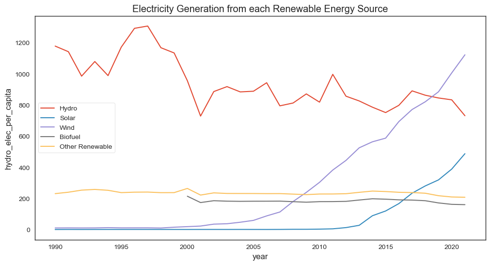

```python
# The original plot was interactive, but I modified it to be non-interactive for conversion to an HTML file.
# To make the plot interactive again, uncomment the code inside the f function and adjust its indentation.

#@interact(Country = G7_Countries)

#def f(Country):
df2 = df_WE_G7[df_WE_G7['country'] == Country]
sns.lineplot(x="year", y="hydro_elec_per_capita", data=df2, label='Hydro').set(title = "Electricity Generation from each Renewable Energy Source")
sns.lineplot(x="year", y="solar_elec_per_capita", data=df2, label='Solar')
sns.lineplot(x="year", y="wind_elec_per_capita", data=df2, label='Wind')
sns.lineplot(x="year", y="biofuel_elec_per_capita", data=df2, label='Biofuel')
sns.lineplot(x="year", y="other_renewables_elec_per_capita", data=df2, label='Other Renewable')
#    return
```

## 8. World Energy Overview

https://geopandas.org/en/stable/docs/user_guide/interactive_mapping.html

```python
# Changing the name of United States
df_WE_all.loc[df_WE_all['country'] == 'United States', 'country'] = 'United States of America'
```

```python
# Creating new DataFrame for everage of consumption between 1990 to 2021

df_tmp = df_WE_all[df_WE_all.year.between(1990, 2022)].groupby('country').agg({'energy_per_capita':['mean'], 'net_elec_imports':['mean'], 'per_capita_electricity':['mean'],
                                          'fossil_elec_per_capita':['mean'], 'nuclear_elec_per_capita':['mean'], 'renewables_elec_per_capita':['mean']}).reset_index()

df_tmp.columns = ['Country', 'Energy_Consumption_PerCapita', 'Net_Electricity_Imports', 'Electricity_Comsumption_PerCapita',
                  'Electricity_from_Fossil_PerCapita', 'Electricity_from_Nuclear_PerCapita', 'Electricity_from_Renewables_PerCapita']
#df_tmp
```

```python
nybb = geopandas.read_file(geopandas.datasets.get_path('nybb'))
world = geopandas.read_file(geopandas.datasets.get_path('naturalearth_lowres'))
cities = geopandas.read_file(geopandas.datasets.get_path('naturalearth_cities'))
```

```python
world = pd.merge(left=world, right=df_tmp, how='left', left_on='name', right_on='Country')
```

```python
world.drop(world[world.name.isnull() == True].index, inplace=True)
```

```python
world.drop(world[world.Energy_Consumption_PerCapita.isnull() == True].index, inplace=True)
```

```python
# The original plot was interactive, but I modified it to be non-interactive for conversion to an HTML file.
# To make the plot interactive again, uncomment the code inside the f function and adjust its indentation.

energyTypeWorld = ['Energy_Consumption_PerCapita', 'Net_Electricity_Imports', 'Electricity_Comsumption_PerCapita', 'Electricity_from_Fossil_PerCapita',
                  'Electricity_from_Nuclear_PerCapita', 'Electricity_from_Renewables_PerCapita']


tooltipList = ['Country', 'Energy_Consumption_PerCapita', 'Net_Electricity_Imports', 'Electricity_Comsumption_PerCapita', 'Electricity_from_Fossil_PerCapita',
                  'Electricity_from_Nuclear_PerCapita', 'Electricity_from_Renewables_PerCapita']

EnergyType = 'Energy_Consumption_PerCapita'


#@interact(EnergyType = energyTypeWorld)

#def f(EnergyType):
m = world.explore(
        column=EnergyType,  # make choropleth based on "BoroName" column
        scheme="quantiles",  # use mapclassify's natural breaks scheme
        legend=True, # show legend
        cmap='OrRd',
        k=10, # use 10 bins
        legend_kwds=dict(colorbar=False), # do not use colorbar
        tooltip=tooltipList,
        tooltip_kwds=dict(labels=True), # do not show column label in the tooltip
        name="countries" # name of the layer in the map
    )
#    return m
m
```

Make this Notebook Trusted to load map: File -> Trust Notebook

[interactive chart not shown]